# 01_BDCC_Lab2_Main

```python
%%HTML
<script src="require.js"></script>
```

```python
## Install Packages
# pip install pyspark
# pip install pyarrow
# pip install matplotlib
# pip install wordcloud
```

```python
# HTML code to toggle code cell visibility
from IPython.display import HTML
HTML('''<script src="https://cdnjs.cloudflare.com/ajax/libs/jquery/2.0.3/
jquery.min.js "></script><script>
code_show=true;
function code_toggle() {
if (code_show){
$('div.jp-CodeCell > div.jp-Cell-inputWrapper').hide();
} else {
$('div.jp-CodeCell > div.jp-Cell-inputWrapper').show();
}
code_show = !code_show
}
$( document ).ready(code_toggle);</script><form action="
javascript:code_toggle()"><input type="submit"
value="Click here to toggle on/off the raw code."></form>
''')
```

[figure not shown]

# EXECUTIVE SUMMARY

In the digital era, data-driven decision making has become a necessity, providing a competitive advantage for businesses. This study aimed to leverage the Amazon-PQA dataset to uncover insights from customer queries and product information, with the goal of improving product descriptions, customer service, and marketing strategies which revolves around answering the following problem statement:

**How can we leverage the Amazon-PQA dataset to understand customer queries and product information better, and use this understanding to improve product descriptions, customer service, and marketing strategies?**

The motivation behind this study was not only to enhance sales growth or service but to gain a deeper understanding of our customers and create an enhanced shopping experience tailored to individual preferences and needs.

The methodology involved three main steps: `data collection`, `data preprocessing and exploratory data analysis (EDA)`, and detailed `data analysis & visualization`. The data was collected from Amazon Q&A JSON files and loaded into a Spark DataFrame. After data preprocessing and EDA, a more detailed analysis was performed to uncover key insights.

The analysis revealed that the most common product category was `unlocked cell phones`, and the most common brand name was an empty string, indicating many products are `unbranded` or the brand is not specified. The item with the most questions was the `Fire TV Stick with Alexa Voice Remote`, suggesting that this product generates a lot of customer interest or has unclear product descriptions. The majority of the top 10 product categories were `tech-related`, suggesting a strong customer interest in these areas. The top brands in the dataset were well-known tech giants such as `Amazon, Samsung, ASUS, Sony, HP, Apple, Acer, and Dell`.

Based on these insights, several recommendations were made for immediate implementation and future work. For immediate implementation, it was recommended to `improve product descriptions, enhance customer service, and optimize marketing strategies`. A formula for structuring product descriptions was also provided as follows:

**[Product Name] + [Key Features] + [Specifications] + [Compatibility Information] + [Usage Instructions] + [Support and Warranty Information]**

For future work, it was suggested to conduct `temporal analysis`, `expand analysis to other platforms`, incorporate `sentiment analysis`, `personalize customer service`, and test and refine recommendations.

This study provides a comprehensive understanding of customer queries and product information, offering valuable insights to improve product descriptions, customer service, and marketing strategies. By implementing the recommendations, Amazon and retailers can enhance their offerings, amplify customer satisfaction, and drive revenue growth.

# TABLE OF CONTENTS

- EXECUTIVE SUMMARY
- LIBRARIES & FUNCTIONS
1. PROBLEM STATEMENT
2. MOTIVATION
3. METHODOLOGY
4. DATA COLLECTION
   1. Data Source
   2. Data Description
   3. Data Collection
5. DATA PREPROCESSING AND EDA
6. DATA ANALYSIS & VISUALIZATION
7. RESULTS AND DISCUSSION
8. CONCLUSION
9. RECOMMENDATION
   1. Limitations of the Study
   2. Recommendation
   3. Future Work
- REFERENCES

## List of Tables

- Table 1. Methodology Details
- Table 2. Data Description of Features Used
- Table 3. Mode: Most Common Values of Specified Columns

## List of Figures

- Figure 1. Methodology
- Figure 2. Plot Top 10 Product Categories
- Figure 3. Plot Top 10 Brands
- Figure 4. Plot Top 10 Products
- Figure 5. Plot Distribution By Question Type
- Figure 6. Plot Distribution By Aggregated Answers
- Figure 7. Word Cloud on Questions
- Figure 8. Word Cloud on Answers
- Figure 9. Word Cloud on Product Description

Back to TOC

# LIBRARIES AND FUNCTIONS

This section establishes the initial steps for the subsequent analysis by importing the necessary libraries and defining the required functions. These includes global libraries and helper functions, which serve as the foundation for the analysis process.

## Global Libraries

```python
# Import Libraries and modules
from pyspark.sql import SparkSession
import pyspark.pandas as ps
import pyspark.sql.functions as F
from pyspark.sql.functions import (isnan, when, count, col, avg, desc, length, udf, lower,
                                   sum, format_number, expr, size, lit, explode, split,
                                   udf, explode)
from pyspark.sql.types import (IntegerType, TimestampType, DoubleType,
                               StringType, LongType, StructType, StructField,
                               ArrayType)


from IPython.display import HTML
from IPython.display import display, display_html
import boto3
import numpy as np
import pandas as pd
import os
import glob
import re
import matplotlib.pyplot as plt
import matplotlib.ticker as ticker
from matplotlib.ticker import FuncFormatter
from wordcloud import WordCloud, STOPWORDS
import multiprocessing
import warnings


# Global settings
pd.set_option('display.max_columns', None)
pd.set_option('display.max_colwidth', None)
pd.set_option('display.max_rows', 30)


# Hide warnings
warnings.filterwarnings("ignore")


# Global variables
c_darkorange = '#f56802'
c_midorange = '#FA9634'
c_orange = '#ffc366'
c_darkblue = '#324065'
c_lightblue = '#A7BED3'
c_black = '#131921'
colors = ['#f56802', '#ffc366', '#324065', '#131921'] # Custom color palette
c_oranges = plt.get_cmap('Oranges')(np.linspace(0.15, 0.60, 10))
```

## Helper Functions

```python
# Define Global Helper Functions
def preview_df(data_label, df, display_df=True, display_nulls=False):
    """Displays the data label, number of data points and features, columns
    with null values, and preview of the DataFrame.
    """
    # Calculate the number of data points and features
    num_data_points = df.count()
    num_features = len(df.columns)

    # Display the results
    display(HTML(f"<b><span style='color:#f56802;'>Data Label: "
                 f"</span>{data_label}</b>"))
    display(HTML(f"<b><span style='color:#f56802;'>Number of Data Points: "
                 f"</span>{num_data_points:,.0f}</b>"))
    display(HTML(f"<b><span style='color:#f56802;'>Number of Features: "
                 f"</span>{num_features:,.0f}</b>"))

    # Iterate over all columns and check for null values
    null_columns = []
    for column in df.columns:
        null_count = df.filter(col(column).isNull()).count()
        if null_count > 0:
            null_columns.append((column, null_count))

    # Create a new DataFrame with columns and their null counts
    if null_columns:    # Check if null_columns is not empty
        null_columns_df = spark.createDataFrame(null_columns,
                                                ["Column", "Null Count"])
        display(HTML(f"<b><span style='color:#f56802;'>Columns with "
                     f"null values:</span></b>"))
        display(null_columns_df.toPandas())
    else:
        display(HTML(f"<b><span style='color:#f56802;'>No columns with null "
                     f"values</span></b>"))

    # If display_df=True, display 1 sample row of the current dataframe
    if display_df:
        display(HTML(f"<b><span style='color:#f56802;'>Preview of the "
                     f"dataframe:</span></b>"))
        display(df.limit(1).toPandas())


def display_mode(columns):
    """Returns the mode for each specified column (list) in the given
    PySpark DataFrame.

    Args:
        columns (list): List of column names to calculate mode for.
    """
    display(HTML(f'<left><span style="color:gray; font-size:16px"><b>Table'
                 f' 3. </b>Mode: Most Common Values of Specified '
                 f'Columns</span></left>'))

    # Calculate mode for each column
    modes = []
    for column in columns:
        mode = pqa_all.groupBy(column).count().orderBy(desc('count')).first()
        modes.append((column, mode[column], mode['count']))

    # Create a Pandas DataFrame from the modes
    df_modes = pd.DataFrame(modes, columns=['Column',
                                            'Most Common Value',
                                            'Count'])

    # Display the modes
    display(df_modes)


def plot_top_product_categories(pqa_all):
    """Plots the top 10 product categories based on count."""
    top_categories = (pqa_all
                       .groupBy('product_category')
                       .agg(count('*').alias('count'))
                       .sort('count', ascending=False)
                       .limit(10)
                       .toPandas())

    # Create the vertical bar plot with reversed order
    fig, ax = plt.subplots(figsize=(8, 6))
    ax.barh(top_categories['product_category'][::-1],  # Reverse the order
            top_categories['count'][::-1],  # Reverse the order of counts
            color=[c_darkorange, c_midorange, c_darkorange, c_darkorange,
                   c_darkorange, c_midorange, c_orange,  c_darkorange,
                   c_darkorange, c_orange][::-1])
    ax.set_xlabel('Count (Thousands)', fontsize=16)
    ax.set_ylabel('Product Category', fontsize=16)
    ax.set_title('Tech and Accessories Product Categories Dominate PQA',
                 fontsize=20, fontweight='bold', color='#f56802')
    ax.tick_params(axis='y', rotation=0)

    # Format the y-axis labels in thousands
    ax.xaxis.set_major_formatter(ticker.FuncFormatter(lambda x,
                                                      pos: f'{x/1e3:.1f}K'))

    plt.tight_layout()
    plt.show()



def plot_top_brands(pqa_all, n=10):
    """Plots the top n brands with the most questions."""
    # Count the number of questions for each brand
    brand_counts = (pqa_all
                    .groupby('brand_name')
                    .count()
                    .orderBy('count', ascending=False)
                    .limit(n+1)
                    .toPandas())

    # Create the vertical bar plot with reversed order
    fig, ax = plt.subplots(figsize=(8, 6))
    ax.barh(brand_counts['brand_name'][1:][::-1],  # Reverse the order
            brand_counts['count'][1:][::-1],  # Reverse the order of counts
            color=[c_darkorange, c_darkorange, c_darkorange,
                   c_darkorange, c_darkorange, c_darkorange,
                   c_darkorange, c_orange, c_orange, c_darkorange][::-1])
    ax.set_xlabel('Count (Thousands)', fontsize=16)
    ax.set_ylabel('Brand Name', fontsize=16)
    ax.set_title("Tech Talk: 10 Most Discussed Brands in PQA",
                 fontsize=20, fontweight='bold', color='#f56802')
    ax.tick_params(axis='y', rotation=0)

    # Format the y-axis labels in thousands
    ax.xaxis.set_major_formatter(ticker.FuncFormatter(lambda x,
                                                      pos: f'{x/1e3:.1f}K'))

    plt.tight_layout()
    plt.show()


def plot_top_products(pqa_all, n=10, max_length=25):
    """Plots the top n products with the most questions."""
    # Count the number of questions for each product
    product_counts = (pqa_all
                      .groupby('item_name')
                      .count()
                      .orderBy('count', ascending=False)
                      .limit(n)
                      .toPandas())

    # Truncate the item names
    product_counts['item_name'] = product_counts['item_name'].apply(
        lambda x: (x[:max_length] + '...') if len(x) > max_length else x)

    # Create the vertical bar plot with reversed order
    fig, ax = plt.subplots(figsize=(8, 6))
    ax.barh(product_counts['item_name'][::-1],  # Reverse the order
            product_counts['count'][::-1],  # Reverse the order of counts
            color=c_oranges)
    ax.set_xlabel('Count (Thousands)', fontsize=16)
    ax.set_ylabel('Item Name', fontsize=16)
    ax.set_title("Amazon Ruled Top 10 Products in PQA",
                 fontsize=20, fontweight='bold', color='#f56802')
    ax.tick_params(axis='y', rotation=0)

    # Format the y-axis labels in thousands
    ax.xaxis.set_major_formatter(ticker.FuncFormatter(lambda x,
                                                      pos: f'{x/1e3:.1f}K'))

    plt.tight_layout()
    plt.show()


def plot_question_type_distribution(pqa_all):
    """Plots the distribution of question types in the dataset."""
    # Count the number of each question type
    question_type_counts = pqa_all.groupby('question_type').count().toPandas()


    # Plot the distribution
    fig, ax = plt.subplots(figsize=(8, 6))
    ax.bar(question_type_counts['question_type'],
           question_type_counts['count'],
           color=[c_darkorange, c_orange])
    ax.set_xlabel('Count (Millions)', fontsize=16)
    ax.set_ylabel('Question Type', fontsize=16)
    ax.set_title("Yes-No Queries Prevailed in PQA",
                 fontsize=20, fontweight='bold', color='#f56802')
    ax.tick_params(axis='y', rotation=0)

    # Format the y-axis labels in millions
    ax.yaxis.set_major_formatter(
        ticker.FuncFormatter(lambda x, pos: f'{int(x/1e6):,}M'))

    # Move the y-axis to the right
    ax.yaxis.tick_right()

    plt.tight_layout()
    plt.show()


def plot_question_answer_distribution(pqa_all):
    """Plots the distribution of question types and aggregated answers."""
    # Select 'question_type' and 'answer_aggregated' columns,
    # group by these columns, count, order by count, and convert to Pandas
    question_answer_counts = (pqa_all
                            .select('question_type', 'answer_aggregated')
                            .groupby('question_type', 'answer_aggregated')
                            .count()
                            .orderBy(F.desc('count'))
                            .toPandas())

    # Pivot the DataFrame to get counts for each combination of Q and A
    question_type_counts_pivot = (question_answer_counts
                                  .pivot(index='question_type',
                                         columns='answer_aggregated',
                                         values='count'))

    # Create the plot
    fig, ax = plt.subplots(figsize=(8, 6))
    question_type_counts_pivot.plot(kind='bar',
                                    stacked=True,
                                    ax=ax,
                                    color=[c_darkblue,
                                           c_darkorange,
                                           c_midorange,
                                           c_orange])
    ax.set_xlabel('Question Type', fontsize=16)
    ax.set_ylabel('Count (Millions)', fontsize=16)
    ax.set_title("N/A and Neutral Answers Make Up 70% of PQA",
                 fontsize=20, fontweight='bold', color='#f56802')
    ax.tick_params(axis='y', rotation=0)

    # Format the y-axis labels in millions
    ax.yaxis.set_major_formatter(ticker
                                 .FuncFormatter(lambda x,
                                                pos: f'{int(x/1e6):,}M'))
    ax.yaxis.tick_right()  # Move the y-axis to the right
    plt.tight_layout()
    plt.show()


# Add additional words to stopwords
additional_stopwords = ["will", "one", "come", "want", "know", "see",
                        "go", "get", "thanks", "thank", "im",
                       "X", "x", "1", "2", "3", "4", "5", "6", "7", "8", "9",
                       "dont", "mine", "think", "us", "hi",
                        "hello", "dear", "cant", "ive", "didnt"]

STOPWORDS = STOPWORDS.union(set(additional_stopwords))

# Compile regex patterns for stopwords and punctuation
pattern = re.compile(r'\b(' + r'|'.join(STOPWORDS) + r')\b\s*')
re_stop = udf(lambda x: re.sub(pattern, '', x))
pattern_punc = re.compile(r'[^\w\s]')
re_punc = udf(lambda x: re.sub(pattern_punc, '', x))

def word_cloud_plot(pqa_all, title, wc_column, is_answer=False):
    """Plot word cloud"""

    # If the column is 'answers', we need to handle it differently
    if is_answer:
        df_tokens = (pqa_all
                    .select(explode(split(re_stop(lower(re_punc(col(wc_column)
                    .getItem(0).cast("string")))), " ")).alias("tokens"))
                    .filter(col('tokens') != '')
                    .filter(length('tokens') > 1)
                    .groupby("tokens")
                    .count()
                    .orderBy(desc("count"))
                    .limit(150)
                    .toPandas())
    else:
        # Tokenize the input DataFrame, remove stopwords and punctuation,
        # group by tokens, count, and order by count
        df_tokens = (pqa_all
                    .select(explode(split(re_stop(re_punc(
                        lower(wc_column)))," "))
                    .alias("tokens"))
                    .filter(col('tokens') != '')
                    .groupby("tokens")
                    .count()
                    .orderBy(desc("count"))
                    .limit(150)
                    .toPandas())

    # Create a dictionary to store word frequencies
    d = {}
    for a, x in df_tokens.values:
        d[a] = x

    # Generate the word cloud
    wordcloud = WordCloud(background_color="white", colormap='autumn')
    wordcloud.generate_from_frequencies(frequencies=d)

    # Plot the word cloud
    fig = plt.figure(figsize = (10, 5))
    plt.title(f"Word Cloud on {title}",
              fontsize=20, fontweight='bold', color='#f56802')
    plt.imshow(wordcloud, interpolation="bilinear")
    plt.axis("off")
    plt.show()
```

Back to TOC

# 1. PROBLEM STATEMENT

Every question asked and every concern raised by a customer carries within it a treasure trove of insights waiting to be uncovered. Our objective is simple yet challenging: to dive deep into the Amazon-PQA dataset, make sense of what our customers are truly seeking, and use these insights to redefine our approach to product descriptions, customer service, and marketing strategies. To turn this objective into something that we can answer, this study revolves around finding an answer to the following research question:

**How can we leverage the Amazon-PQA dataset to understand customer queries and product information better, and use this understanding to improve product descriptions, customer service, and marketing strategies?**

Back to TOC

# 2. MOTIVATION

In today's digital era, the importance of data-driven decision making cannot be overstated. It is not only a competitive advantage but also a necessity. Our objective of leveraging the Amazon-PQA dataset aligns perfectly with this mindset, as we aim to utilize data to enhance product descriptions, optimize customer service, and refine marketing strategies.

By delving into the Amazon-PQA dataset, we have the opportunity to unlock a wealth of customer insights, which in turn will enable us to improve various aspects of Amazon's and retailers' business operations. However, our focus goes beyond mere sales growth or service enhancement; it revolves around gaining a deeper understanding of our customers. The ultimate goal is to create an enhanced shopping experience that is tailored to the individual preferences and needs of each customer in the e-commerce industry.

With this project, we envision a win-win scenario: Amazon's and e-commerce retailers' services and sales will see improvements, while customers will benefit from a more personalized and satisfying shopping experience.

Back to TOC

# 3. METHODOLOGY

[figure not shown]

**Figure 1.** Methodology

As depicted in **Figure 1: Methodology**, the methodology of this project follows a three-step process: data collection, preprocessing, and analysis. Further details are elaborated in **Table 1: Methodology Details**.

**Table 1.** Methodology Details

[output not shown]

Back to TOC

# 4. DATA COLLECTION

The first step in the data collection methodology is to retrieve the necessary data. In this case, we will focus on accessing the Amazon-PQA dataset, which contains customer questions and corresponding answers regarding products on Amazon. This dataset holds valuable insights into customer queries, preferences, and concerns.

The **three key steps** involved in data collection section are as follows:

- Identifying the **data source**
- **Describing the data**
- **Collecting the data**

## 4.1 Data Source

The primary dataset for this study is the **Amazon Product Questions and Answers (Amazon-PQA)** dataset, which consists of an extensive collection of customer queries and responses in August 2020 related to a diverse range of Amazon products. This dataset was sourced from **AWS OpenData** and was originally used in the study "Answering Product-Questions by Utilizing Questions from Other Contextually Similar Products," authored by (Rozen et al., 2021) and presented at the 2021 Conference of the North American Chapter of the Association for Computational Linguistics: Human Language Technologies.

The **Amazon PQA** dataset is stored in an S3 bucket with Amazon Resource Name `arn:aws:s3:::amazon-pqa` located in the `us-east-1` region. It consists of 100 JSON files, each representing a different product category. The total uncompressed size of the dataset is **17.3 GB.**

## 4.2 Data Description

In this subsection, the data dictionaries of each dataset are summarized, providing details about the description, and data type of each feature. This aids in understanding the data and identifying any data quality issues that may require preprocessing.

**Table 2** provides a summary description of the relevant features used in this study.

Data from Amazon-PQA Dataset: (Amazon PQA)

- **Number of Data Points: 9,989,014**
- **Number of Features: 15**

**Table 2.** Data Description of Features Used

[output not shown]

These fields collectively provide a comprehensive understanding of the product in question and the customer queries associated with it. The dataset is meticulously organized by categories, providing a structured format that supports efficient data analysis.

## 4.3 Data Collection

The following steps illustrate the process of collecting and loading the dataset into a Spark DataFrame, then assigning the appropriate schema.

### 4.3.1 Create a Spark Session

```python
# Create a Spark Session
spark = (SparkSession
           .builder
           .master('local[*]')
           .config('spark.jars.packages',
                'com.amazonaws:aws-java-sdk:1.12.467,'
                'org.apache.hadoop:hadoop-aws:3.3.2')
           .config('spark.executor.extraJavaOptions',
                '-Dcom.amazonaws.services.s3.enableV4=true')
           .config('spark.driver.extraJavaOptions',
                '-Dcom.amazonaws.services.s3.enableV4=true')
           .config('spark.hadoop.fs.s3a.aws.credentials.provider',
                   'org.apache.hadoop.fs.s3a.AnonymousAWSCredentialsProvider')
           .getOrCreate())

# Disable logging messages
spark.sparkContext.setLogLevel('OFF')
display(HTML(f"<b>SparkSession created.</b>"))
```

**SparkSession created.**

### 4.3.2 Load and store the dataset in a Spark DataFrame format

This subsection encompasses several operations, including reading the dataset using `spark.read.json()`, assigning the schema, displaying a preview of the dataframe, and obtaining the row, column, and null value counts.

```python
# Define the schema
schema = StructType([
    StructField("answer_aggregated", StringType(), True),
    StructField("answers", ArrayType(
        StructType([
            StructField("answer_text", StringType(), True)
        ])
    ), True),
    StructField("asin", StringType(), True),
    StructField("brand_name", StringType(), True),
    StructField("bullet_point1", StringType(), True),
    StructField("bullet_point2", StringType(), True),
    StructField("bullet_point3", StringType(), True),
    StructField("bullet_point4", StringType(), True),
    StructField("bullet_point5", StringType(), True),
    StructField("item_name", StringType(), True),
    StructField("product_description", StringType(), True),
    StructField("question_id", StringType(), True),
    StructField("question_text", StringType(), True),
    StructField("question_type", StringType(), True),
    StructField("product_category", StringType(), True)
])
```

```python
s3 = boto3.resource('s3')
bucket = s3.Bucket('amazon-pqa')

# Get list of all .json files in the bucket
json_files = ([obj
               .key for obj in bucket
               .objects
               .all() if obj.key.endswith('.json')])

# Extract product category from file name
product_categories = ([os
                       .path
                       .basename(file)
                       .replace('amazon_pqa_', '')
                       .replace('.json', '') for file in json_files])

# Initialize an empty dataframe same as the defined schema
pqa_all = spark.createDataFrame([], schema)

# Loop over all files
for json_file in json_files:
    # Read the json file from S3
    df = spark.read.json("s3a://amazon-pqa/" + json_file)

    # Extract product category from the filename
    product_category = (os
                        .path
                        .basename(json_file)
                        .replace('amazon_pqa_', '')
                        .replace('.json', ''))

    # Add the product category as a new column
    df = df.withColumn('product_category', lit(product_category))

    # Concatenate the dataframe with the main dataframe
    pqa_all = pqa_all.union(df)


# Display the schema
display(HTML(f"<b><span style='color:#f56802;'>Amazon PQA Dataset "
             f"Schema:</span></b>"))
pqa_all.printSchema()
```

**Amazon PQA Dataset Schema:**

```
root
 |-- answer_aggregated: string (nullable = true)
 |-- answers: array (nullable = true)
 |    |-- element: struct (containsNull = true)
 |    |    |-- answer_text: string (nullable = true)
 |-- asin: string (nullable = true)
 |-- brand_name: string (nullable = true)
 |-- bullet_point1: string (nullable = true)
 |-- bullet_point2: string (nullable = true)
 |-- bullet_point3: string (nullable = true)
 |-- bullet_point4: string (nullable = true)
 |-- bullet_point5: string (nullable = true)
 |-- item_name: string (nullable = true)
 |-- product_description: string (nullable = true)
 |-- question_id: string (nullable = true)
 |-- question_text: string (nullable = true)
 |-- question_type: string (nullable = true)
 |-- product_category: string (nullable = true)
```

Back to TOC

# 5. DATA PREPROCESSING AND EDA

In this section, the datasets undergo preprocessing and cleaning procedures, including handling missing values, filtering out of irrelevant records, along with other exploratory data analysis (EDA) techniques. These steps guarantee that the datasets are prepared for analysis and that the resulting insights derived from the data are dependable.

## 5.1 Preview Data, Check for Null Values

```python
preview_df(data_label="Amazon PQA Dataset",
           df=pqa_all,
           display_nulls=True)
```

**Data Label: Amazon PQA Dataset**

**Number of Data Points: 9,989,014**

**Number of Features: 15**

**No columns with null values**

**Preview of the dataframe:**

|  | answer_aggregated | answers | asin | brand_name | bullet_point1 | bullet_point2 | bullet_point3 | bullet_point4 | bullet_point5 | item_name | product_description | question_id | question_text | question_type | product_category |
| --- | --- | --- | --- | --- | --- | --- | --- | --- | --- | --- | --- | --- | --- | --- | --- |
| 0 | N/A | [(Plastic,)] | B009360BEW |  | Use the Deck Washer to quickly clean your deck, driveway, sidewalk or garage | The Deck Washer is easy to use -- just attach to a standard garden hose | Built-in nozzles on the broom provide pressure washing while the bristles scrub embedded dirt |  |  | Deck Washer | Instead of sweeping off your deck and then hosing the grime away, do it all at once with the Deck Washer. Simply attach the Deck Washer's aluminum extension handle to your garden hose and wash away st… | Tx3223771NA0J0W | Is the end where the garden hose attaches plastic or metal or brass | WH | accessories |

The dataset consists of 9.9 million data points and 15 features. More importantly, it is complete, with no null values, so we can now proceed to the next step.

## 5.2 Display Statistics

Considering that all the columns in the dataset are of string type or alphanumeric, using descriptive statistics such as mean, median, and standard deviation are not applicable. Therefore, in this section, we focused on obtaining the mode or the most frequently occurring values for the `product_category`, `brand_name`, `item_name`, and `question_type` columns. These columns provide valuable insights into the most common categories, brands, item names, and question types present in the dataset that could later assist or give further value during data analysis and visualization part.

```python
# Display the mode most common values for the given columns
display_mode(columns=['product_category', 'brand_name', 'item_name', 'question_type'])
```

**Table 3.** Mode: Most Common Values of Specified Columns

|  | Column | Most Common Value | Count |
| --- | --- | --- | --- |
| 0 | product_category | unlocked_cell_phones | 499539 |
| 1 | brand_name |  | 5313314 |
| 2 | item_name | Fire TV Stick with Alexa Voice Remote, streaming media player - Previous Generation | 33285 |
| 3 | question_type | yes-no | 5404233 |

**COMMENTS/INSIGHTS:**

- **Product Category**: Table 3 shows that the most common product category in the dataset is `unlocked_cell_phones` with 499,539 occurrences. This means that the dataset contains a significant amount of questions and answers related to unlocked cell phones. This could either mean that there is a high popularity and demand for unlocked cell phones that led to more customer inquiries or the items for this category have unclear product descriptions.
- **Brand Name**: The most common value for the brand name is an empty string (""), with 5,313,314 occurrences. Apparently, even though our initial check for null values in the previous subsection revealed no null values, we discovered that some columns contain empty spaces as values, specifically in the this column where unbranded items sold on Amazon are prevalent. This could be due to various reasons such as the data not being collected, the product being generic or not associated with a specific brand, or the brand name being irrelevant to the question or answer. Since these items without brand names constitute at least 53% of the dataset, we decided to retain these entries and adapt the data analysis approach in subsequent sections to accommodate the presence of these no-brand-name items.
- **Item Name**: The item with the most questions is the `Fire TV Stick with Alexa Voice Remote, streaming media player - Previous Generation` with 33,285 occurrences. This suggests that this particular product either has generated a lot of customer interest and inquiries or has unclear product description. Queries could also be related to its features, performance, or issues that customers have encountered.
- **Question Type**: The most common type of question is `yes-no` with 5,404,233 occurrences. This indicates that a majority of the questions in the dataset are binary, requiring a simple "yes" or "no" answer. This could be because these types of questions are straightforward and easy for customers to ask and for others to answer.

All these will be further investigated in the subsequent sections.

## 5.3 Display Cleaned Dataset

```python
# Display sample rows of the cleaned dataset
display(pqa_all.limit(3).toPandas())
```

|  | answer_aggregated | answers | asin | brand_name | bullet_point1 | bullet_point2 | bullet_point3 | bullet_point4 | bullet_point5 | item_name | product_description | question_id | question_text | question_type | product_category |
| --- | --- | --- | --- | --- | --- | --- | --- | --- | --- | --- | --- | --- | --- | --- | --- |
| 0 | N/A | [(Plastic,)] | B009360BEW |  | Use the Deck Washer to quickly clean your deck, driveway, sidewalk or garage | The Deck Washer is easy to use -- just attach to a standard garden hose | Built-in nozzles on the broom provide pressure washing while the bristles scrub embedded dirt |  |  | Deck Washer | Instead of sweeping off your deck and then hosing the grime away, do it all at once with the Deck Washer. Simply attach the Deck Washer's aluminum extension handle to your garden hose and wash away st… | Tx3223771NA0J0W | Is the end where the garden hose attaches plastic or metal or brass | WH | accessories |
| 1 | N/A | [(No, it does not.,), (no,)] | B00E63VX26 | Fia | Vehicle tested before engineering approval | Ease of installation with Super-Grip slip resistant fastening system using quick release buckle fasteners, Velcro and zippers (some applications) | Light fast, color fast materials will not run or fade and can be hand washed | Form fit wrap around design - multidirectional stretch trim molds to the contours of the seat | Center armrest/console covers and headrest covers included (most applications) | Fia TR49-39 BLACK Custom Fit Front Seat Cover Bucket Seats - Saddle Blanket, (Black) |  | TxASRMZNTT0NON | Does the 20% middle portion, or arm rest, get covered by this seat cover? | WH | accessories |
| 2 | no | [(No it does not cover center seat of bench, nor console,)] | B00E63VX26 | Fia | Vehicle tested before engineering approval | Ease of installation with Super-Grip slip resistant fastening system using quick release buckle fasteners, Velcro and zippers (some applications) | Light fast, color fast materials will not run or fade and can be hand washed | Form fit wrap around design - multidirectional stretch trim molds to the contours of the seat | Center armrest/console covers and headrest covers included (most applications) | Fia TR49-39 BLACK Custom Fit Front Seat Cover Bucket Seats - Saddle Blanket, (Black) |  | Tx3PT0N7PHAZ6I0 | Is this kit supposed to include a cover for the center console as shown? | yes-no | accessories |

Back to TOC

# 6. DATA ANALYSIS AND VISUALIZATION

The data analysis and visualization section aims to uncover valuable insights from the dataset using various analytical techniques and visualization tools. This section utilizes Apache Spark DataFrame, Pandas, and Matplotlib to perform descriptive analytics and gain a comprehensive understanding of the data. The following key aspects will be addressed:

**Descriptive Analytics:**

- Utilize Apache Spark DataFrame to explore the dataset.
- Analyze questions and answers by product category, brand, item names, and other relevant features to gain insights from the data.

**Data Visualization:**

- Visualize the results of the analysis to enhance comprehension and communication of key findings.
- Utilize appropriate charts, graphs, and plots to present patterns, trends, and relationships in the data.
- Create meaningful visual representations of the features for an interpretable communication of insights.

## 6.1 Top 10 Product Categories

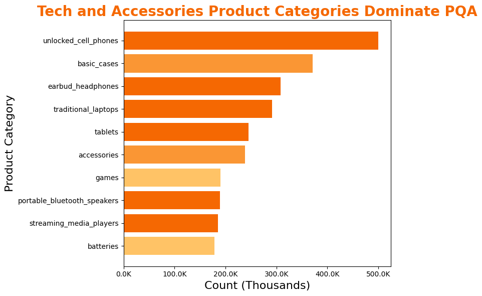

```python
# Plot the Top 10 Product Categories
plot_top_product_categories(pqa_all)
```

**Figure 2.** Plot Top 10 Product Categories

**COMMENTS/INSIGHTS:**

- **High Interest in Tech Products**: Figure 2 reveals that the majority of the top 10 product categories are tech-related, including `unlocked cell phones`, `earbud headphones`, `traditional laptops`, `tablets`, `portable bluetooth speakers`, and `streaming media players`. This suggests a high level of customer engagement and queries in these areas, indicating a strong interest or potential issues that need addressing.
- **Accessories and Basic Cases**: The presence of `basic cases` and `accessories` in the top categories suggests that customers are not just interested in the main products, but also in complementary items. This could indicate a need for bundled offers or more detailed information on compatibility and features of these accessories.
- **Batteries and Games**: The inclusion of `batteries` and `games` in the top 10 indicates specific areas where customers might have more questions or concerns, possibly due to performance or compatibility issues.

These insights can be leveraged to improve **product descriptions** by focusing on areas where customers have the most queries. For **customer service**, understanding the common issues in these top categories can help in training representatives and preparing resources. For **marketing strategies**, these insights can guide the promotion of products and bundles that are likely to attract customer interest. The existence of complementary items in the top 10 indicates potential cross-selling opportunities where relevant accessories can be recommended to customers during their purchasing journey, ultimately enhancing customer satisfaction and increasing revenue.

## 6.2 Top 10 Brands

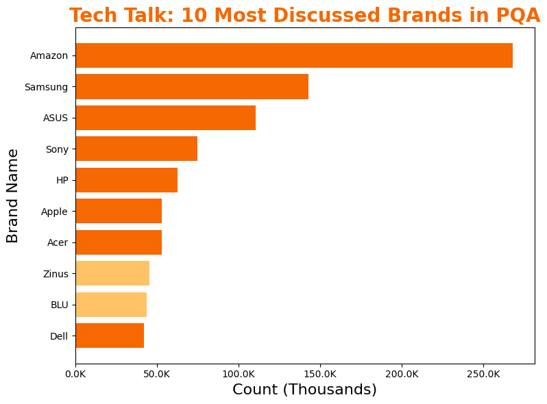

```python
# Plot Top 10 Brands
plot_top_brands(pqa_all, n=10)
```

**Figure 3.** Plot Top 10 Brands

**COMMENTS/INSIGHTS:**

Figure 3 shows that the top brands in the dataset are well-known tech giants such as Amazon, Samsung, ASUS, Sony, HP, Apple, Acer, and Dell. This indicates that these brands dominate the market and are the most discussed among customers. The following insights were also noted:

- **Product-Brand Correlation**: The dominance of tech brands aligns with the top product categories which were mostly tech-related (e.g., unlocked cell phones, traditional laptops, tablets). This suggests a strong correlation between the product type and the brand.
- **Unbranded Products:** The high number of unbranded products (5,313,314 queries, excluded in the plot) suggests that many customers are either unsure of the brand of their product or the product is genuinely unbranded. This presents an opportunity for Amazon and retailers to improve product descriptions and categorization to help customers better identify their products.
- **Marketing Strategy:** Brands can leverage this data to understand which products are generating the most customer queries and focus their marketing and customer service efforts accordingly. For instance, Amazon, being the top brand, could invest more in customer education and support for their products.
- **Customer Service Improvement:** The high number of queries for unbranded products indicates a need for better customer support and guidance. Amazon could implement strategies such as improved product categorization, enhanced search functionality, and more detailed product descriptions to assist customers with unbranded products.

## 6.3 Top 10 Products

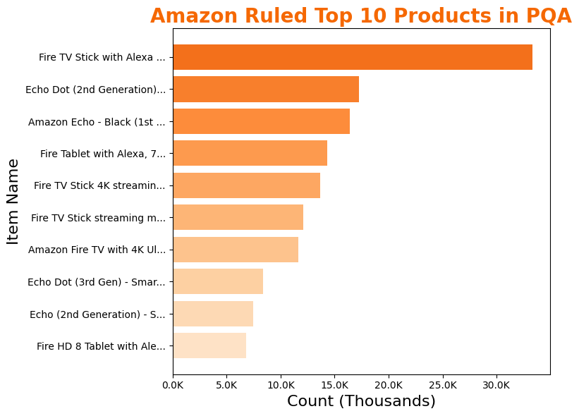

```python
# Plot Top 10 Products
plot_top_products(pqa_all, n=10)
```

**Figure 4.** Plot Top 10 Products

Figure 4 illustrates that the top 10 most discussed products are all Amazon's own products, particularly those related to its Echo and Fire product lines. This suggests that these products generate a significant amount of customer interaction and engagement.

- **Fire TV Stick with Alexa Voice Remote**: This product has the highest number of queries, indicating its popularity among customers. However, the high number of questions could also suggest that customers find certain aspects of this product confusing or difficult to use. It would be beneficial to review the common questions and concerns raised about this product and address them in the product description or a FAQ section.
- **Echo Dot (2nd Generation**: This product also has a high number of queries, suggesting that it is widely used. Similar to the Fire TV Stick, it would be helpful to address common customer queries in the product description or a dedicated FAQ section.
- **Amazon Echo - Black (1st Generation)**: Despite being an older generation product, it still generates a significant number of customer queries. This could indicate a loyal customer base that continues to use this product. It would be worthwhile to provide continued support and resources for these customers.
- **Fire Tablet with Alexa, 7 Display, 8 GB, Black**: This product, like the others, generates a high number of customer queries. It would be beneficial to review these queries and address common issues in the product description or a FAQ section.

The high number of queries related to Amazon's own products suggests that these products are popular but may also be complex or confusing to some customers. It would be beneficial to review the common queries and address them in the product descriptions, FAQ sections, or user manuals.

## 6.4 Plot Distribution By Question Type

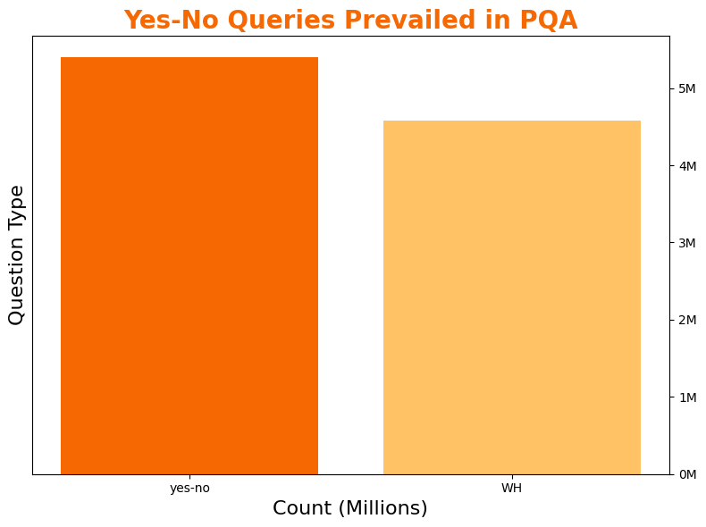

```python
# Plot Distribution By Question Type
plot_question_type_distribution(pqa_all)
```

**Figure 5.** Plot Distribution By Question Type

**COMMENTS/INSIGHTS:**

The distribution of question types, as shown in Figure 5, reveals that there is a nearly equal split between "yes-no" type questions and "WH" type questions (those starting with 'what', 'where', 'when', 'why', 'who', 'which') through which we noted the following:

- **Balanced Distribution:** The nearly equal distribution of **yes-no** and **WH** type questions suggests that customers are not only seeking confirmation or denial (which is typically the case with **yes-no** questions) but are also interested in obtaining detailed information or explanations (which is often the case with **WH** questions). This indicates a diverse range of customer curiosity and information needs.
- **Product Descriptions** The high number of **WH** questions could imply that product descriptions may not be providing enough detailed information that customers are seeking. This could be an opportunity to improve product descriptions by incorporating more detailed and specific information about the products.
- **Customer Service** The high number of **yes-no** questions suggests that customers often need quick confirmations or clarifications. This could be an opportunity to enhance customer service by providing quick and direct responses to such queries.

## 6.5 Plot Distribution By Aggregated Answers

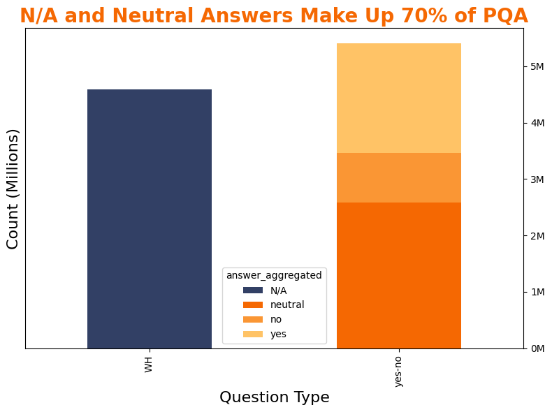

```python
plot_question_answer_distribution(pqa_all)
```

**Figure 6.** Plot Distribution By Aggregated Answers

**COMMENTS/INSIGHTS:**

Continuing with the insights listed in Figure 5, we further examined the distribution of answers (answers_aggregated) for each question type, leading to the following insights:

- **Complex Nature of WH Questions**: The majority of 'WH' type questions (who, what, where, when, why, how) tend to have non-binary answers, indicated by the 'N/A' category. This suggests that these questions require more detailed or subjective responses, reflecting their complexity.
- **Neutrality of Yes-No Questions**: A significant portion of 'yes-no' type questions are labeled as 'neutral'. This suggests that these questions either remain unanswered or receive non-definitive 'yes' or 'no' responses. Attention should be given to address these neutral answers as they indicate a potential gap in customer satisfaction or seller's hesitance to provide clear responses.
- **Positive Trend in Yes-No Responses**: There are more 'yes' answers than 'no' answers for 'yes-no' type questions. This indicates a favorable trend, suggesting that customers often seek confirmation or affirmation rather than raising concerns or objections.

Considering the distribution of question types and aggregated answers in Figure 6, the following additional insights emerge:

- **Lack of Definitive Answers for WH Questions**: Many responses for WH question types fall under 'N/A' and yes-no question types under 'neutral', indicating the absence of clear-cut responses. This can be attributed to the complexity of the questions, limited information available, or the subjective nature of the queries. 'N/A' answers are acceptable for WH questions, but it is important to address the neutral responses in 'yes-no' questions to provide clarity to customers and reduce uncertainties.
- **Emphasizing Product Description**: The higher number of "yes" responses compared to "no" responses in 'yes-no' questions suggests that customers often seek confirmation or validation. This highlights the importance of including relevant information in product descriptions to address common customer queries and reduce the need for confirmation.

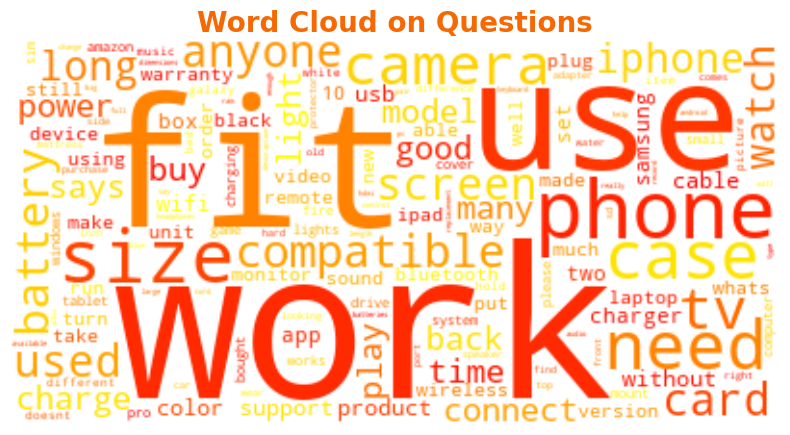

```python
# Word Cloud on Questions
word_cloud_plot(pqa_all, "Questions", 'question_text')
```

**Figure 7.** Word Cloud on Questions

The word cloud in Figure 7 provides a visual representation of the most frequently occurring words in the questions dataset where we noted the following:

- **Product Features and Compatibility:** Words like `work`, `fit`, `use`, `compatible`, `size`, `battery`, `screen`, `power`, `charge`, `model`, `support`, `usb`, `bluetooth`, `wireless`, `wifi`, `sim`, `sd`, `charging` suggest that customers are often asking about the functionality, compatibility, and specifications of the products.
- **Product Types:** Certain product types seem to be more frequently discussed, as indicated by words like `phone`, `camera`, `tv`, `watch`, `card`, `light`, `remote`, `charger`, `video`, `app`, `box`, `ipad`, `monitor`, `galaxy`, `fire`, `windows`, `laptop`, `game`. This could indicate high interest or potentially high complexity or issues related to these products.
- **Product Operations:** Words like `connect`, `play`, `turn`, `run`, `set`, `using`, `make`, `still`, `pair`, `record` suggest that customers often have questions about how to use or operate the products.
- **Product Evaluation:** Words like `good`, `better`, `difference`, `warranty`, `pro`, `really` suggest that customers are often evaluating products or comparing between different products or models.

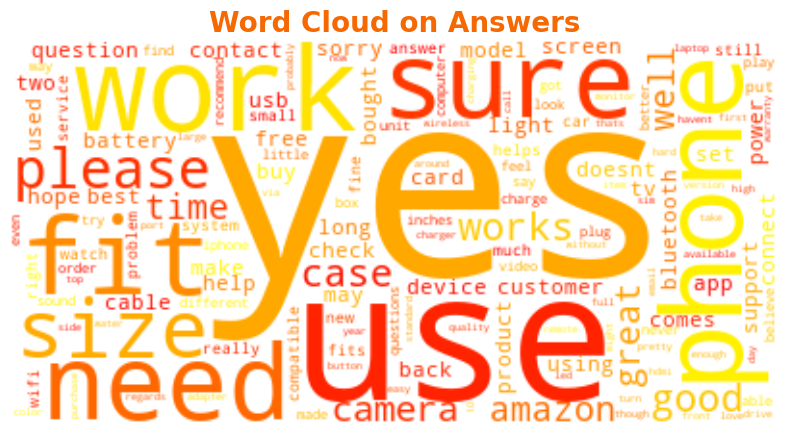

```python
# Word Cloud on Answers
word_cloud_plot(pqa_all, "Answers", 'answers', is_answer=True)
```

**Figure 8.** Word Cloud on Answers

The word cloud in Figure 8 provides a high-level overview of the most common words used in the responses. Here are some insights that we have noted:

- **Product-related responses**: The frequent appearance of words related to specific products or product features (like `phone`, `case`, `camera`, `tv`, `battery`, `usb`, `cable`, `screen`, `bluetooth`, `wifi`, `charger`, `adapter`, `hdmi`, and `monitor`) suggests that sellers or customer support often provide information or clarification about these aspects. This aligns with the previous insight that electronics and accessories are among the top product categories. Sellers are likely addressing questions about product specifications, compatibility, and usage.
- **Action-oriented responses**: Words like `use`, `work`, `fit`, `need`, `buy`, `connect`, `set`, `charge`, `play`, `turn`, `drive` indicate that the responses often involve instructions or explanations about how to use or handle the product. This could imply that customers frequently encounter issues with operating or understanding the functionalities of the products.
- **Quality and experience feedback**: Words like `good`, `great`, `fine`, `better`, `quality`, `love`, `easy` suggest that sellers or customer support often provide reassurances about the product quality or user experience. This could be in response to queries about the product's performance or quality.
- **Customer service-oriented responses**: Words like `please`, `contact`, `support`, `help`, `service`, `question`, `recommend`, `warranty` indicate that the responses often involve directing customers to further assistance, offering support, or providing information about services like warranty. This suggests a proactive approach to customer service.
- **Affirmative responses**: The word `yes` being the most frequent word suggests that many customer queries are yes-no questions, and the responses are often affirmative. This aligns with the previous insight about the prevalence of yes-no questions in the dataset.

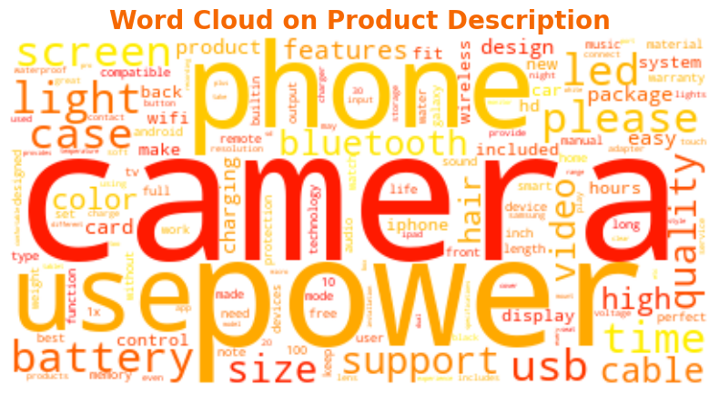

```python
# Word Cloud on Product Description
word_cloud_plot(pqa_all, "Product Description", 'product_description')
```

**Figure 9.** Word Cloud on Product Description

The word cloud in Figure 9 provides insights into the common features and attributes highlighted by sellers. Here are some insights that we have noted:

- **Product Categories**: The frequent appearance of words like `camera`, `phone`, `battery`, `light`, `usb`, `screen`, `case`, `led`, `bluetooth`, `cable`, `video`, `wifi`, `iphone`, `car`, `wireless`, `hd`, `display`, `compatible`, `android`, `tv`, `adapter`, `charger`, `ipad`, `samsung`, `tablet`, `micro`, `sd` suggests that electronics and accessories are a major category of products. This aligns with the previous insight about tech products being among the top product categories.
- **Product Features**: Words like `power`, `support`, `size`, `quality`, `color`, `high`, `features`, `design`, `easy`, `control`, `system`, `new`, `full`, and others indicate that sellers often highlight a wide range of product features in their descriptions. This could include design, quality, compatibility, ease of use, size, color, and specific features like waterproof, wireless, bluetooth, etc.
- **Customer Service**: Words like `please`, `support`, `warranty`, `contact`, `service` suggest that sellers often mention the support and services they provide, such as warranty and customer service, in their product descriptions. Moreover, considering the high frequency of words related to customer service, it's clear that sellers are making an effort to provide excellent customer service. This could be further improved by ensuring that the product descriptions are accurate and comprehensive, reducing the need for customers to reach out for additional information.

Finally, the presence of words like `quality`, `design`, `easy`, `new`, `full`, `smart`, `best`, `made`, `comfortable`, etc., indicates that sellers are emphasizing the quality and ease-of-use of their products. This is a good strategy, as it can help to attract customers who value these attributes. However, it's also important to ensure that these claims are backed up by the actual performance of the products, as any discrepancy could lead to customer dissatisfaction.

Back to TOC

# 7. RESULTS AND DISCUSSION

Our analysis of the Amazon PQA dataset yielded several key insights into the nature of customer queries and the products they pertain to.

- **Product Category and Brand Name**: The most common product category was `unlocked_cell_phones`, indicating a high level of customer engagement in this area. However, the most common brand name was an empty string, suggesting that many products are `unbranded` or the `brand is not specified`. This could be due to the product being generic or the brand name being irrelevant to the question or answer.
- **Item Name and Question Type**: The item with the most questions was the `Fire TV Stick with Alexa Voice Remote`, suggesting that this product generates a lot of customer interest or has unclear product descriptions. The most common type of question was `yes-no`, indicating that customers often seek binary responses.
- **High Interest in Tech Products**: The majority of the top 10 product categories were `tech-related`, suggesting a strong customer interest in these areas. This could indicate a need for more detailed information on these products or potential issues that need addressing.
- **Brand Dominance**: The top brands in the dataset were well-known tech giants such as `Amazon`, `Samsung`, `ASUS`, `Sony`, `HP`, `Apple`, `Acer`, and `Dell`. This indicates that these brands dominate the market and are the most discussed among customers.
- **Amazon's Own Products**: The top 10 most discussed products were all `Amazon's own products`, particularly those related to its `Echo` and `Fire` product lines. This suggests that these products generate a significant amount of customer interaction and engagement.
- **Question Types and Answers**: There was a nearly equal split between `yes-no` type questions and `WH` type questions, suggesting a diverse range of customer curiosity and information needs. Many responses for `WH` question types fell under `N/A` and `yes-no` question types under `neutral`, indicating the absence of clear-cut responses.
- **Word Cloud Analysis**: The word clouds of questions, responses, and product descriptions provided insights into the common `features`, `attributes`, and `issues` highlighted by customers and sellers. Customers often asked about the `functionality`, `compatibility`, and `specifications` of the products, while sellers highlighted a wide range of product `features` in their descriptions and responses.

These insights can be leveraged to `improve product descriptions, customer service, and marketing strategies`. For instance, **product descriptions could be improved by incorporating more detailed and specific information about the products. Customer service could be enhanced by providing quick and direct responses to customer queries. Marketing strategies could be guided by the promotion of products and bundles that are likely to attract customer interest.**

Back to TOC

# 8. CONCLUSION

The analysis of the Amazon PQ&A dataset has provided valuable insights into customer queries and product information. By understanding the most common product categories, brands, and items that customers inquire about, we were able to identify key areas of customer interest and potential confusion. The prevalence of tech-related products and brands in customer queries highlights the need for clear and comprehensive product descriptions in these areas.

Furthermore, the analysis of question types and responses revealed a diverse range of customer curiosity and information needs. The nearly equal distribution of `yes-no` and `WH` type questions suggests that customers are seeking both binary responses and detailed information. The absence of clear-cut responses to many of these questions indicates a potential gap in product information and customer service.

The word cloud analysis of questions, responses, and product descriptions further emphasized the importance of `detailed product information`. Customers often ask about product `functionality`, `compatibility`, and `specifications`, while sellers highlight a wide range of product `features` in their descriptions and responses.

By comprehending and examining the findings of this study and continuously striving to address customers' actual needs, Amazon and retailers can enhance their offerings by providing comprehensive and precise product information, delivering prompt and direct responses to customer inquiries, and showcasing products and packages that are likely to captivate customer attention. Adopting this customer-centric approach will not only amplify customer satisfaction but also drive revenue growth, establishing a mutually beneficial solution for both customers and the business.

Back to TOC

# 9. RECOMMENDATION

## 9.1 Data Assumptions and Limitations

The analyses presented in this report are based on a set of underlying assumptions and limitations associated with the data. Key assumptions and limitations identified during the creation of this report are as follows:

**Assumptions:**

- The data quality and integrity are assumed to be reliable, with minimal missing values and inaccuracies.
- The data collected is assumed to be unbiased and reflective of customers' actual experiences and opinions.
- The dataset is assumed to be a representative sample of all Amazon customer queries. However, it's important to note that the dataset may not cover all product categories or brands equally.
- The analysis assumes that the frequency of queries about a product or brand is indicative of its popularity or complexity. However, it could also be influenced by other factors such as the product's market presence or advertising efforts.
- The classification of questions into 'yes-no' and 'WH' types assumes that these categories adequately capture the nature of customer queries. However, some questions may not fit neatly into these categories.

**Limitations:**

- The dataset only includes queries and responses from Amazon, limiting the generalizability of the findings to other e-commerce platforms.
- The analysis does not account for temporal trends. Customer queries and concerns may change over time due to factors such as product updates, market trends, or seasonal variations.
- The word cloud analysis provides a high-level overview of the most common words but does not capture the context or sentiment of the queries and responses. This has been added in recommendations for future work.
- The dataset might not include a comprehensive representation of all customer interactions and feedback, as it may be limited to specific channels or sources and geographical locations.
- There could be potential selection bias in the dataset, as it may not cover all demographic segments or regions equally.
- The analysis relies solely on the available variables in the dataset, which may not encompass all relevant factors that impact customer behavior or preferences.
- External factors beyond the dataset, such as market conditions or competitive landscape, may influence customer behavior and outcomes but are not considered in the analysis.

## 9.2 For Immediate Implementation

- **Improve Product Descriptions**: Based on the high frequency of questions about product functionality, compatibility, and specifications, sellers should ensure that their product descriptions are clear, comprehensive, and detailed. They should particularly focus on tech-related products, which were among the top queried categories. A formula for structuring product descriptions could be:
  - **[Product Name] + [Key Features] + [Specifications] + [Compatibility Information] + [Usage Instructions] + [Support and Warranty Information]**
- **Enhance Customer Service:** Sellers should provide quick and direct responses to customer queries, particularly 'yes-no' type questions which often seek confirmation or clarification. They should also address the neutral responses in 'yes-no' questions to provide clarity to customers and reduce uncertainties. Continuously update the product description anytime a new question has an answer that is a key information about the product to minimize the same questions from being raised again in the future.
- **Optimize Marketing Strategies**: Sellers should leverage the insights about the most queried products and brands to focus their marketing efforts. They could promote products and bundles that are likely to attract customer interest, such as tech products and their accessories. They could also recommend relevant accessories to customers during their purchasing journey, enhancing customer satisfaction and increasing revenue.

## 9.3 For Future Work

- **Conduct Temporal Analysis**: Future work could explore how customer queries and concerns change over time. This could provide insights into temporal trends and help sellers anticipate and address seasonal variations in customer queries.
- **Expand Analysis to Other Platforms**: The analysis could be extended to other e-commerce platforms to compare customer queries and improve the generalizability of the findings.
- **Incorporate Sentiment Analysis**: Future work could incorporate sentiment analysis to understand the tone of the queries and responses. This could provide additional insights into customer satisfaction and areas of concern.
- **Personalize Customer Service**: Based on the patterns in customer queries, sellers could develop personalized customer service strategies. For instance, they could provide tailored product recommendations or support resources based on the types of questions a customer asks.
- **Test and Refine Recommendations**: The recommendations provided should be tested and refined based on their effectiveness. Sellers could conduct A/B testing to compare different product description formats, customer service practices, or marketing strategies and identify the most effective approaches.
- **Utilize Natural Language Processing Topics**:
  - **Topic Modeling**: Perform topic modeling (like LDA) on the answers to group them into different topics. This could provide more detailed insights into what the common themes or topics are in the answers.
  - **Sentiment Analysis**: Perform sentiment analysis on the answers to understand the overall sentiment (positive, negative, neutral) of the responses.
  - **Further Text Cleaning**: Further clean the text data by removing more stopwords or non-informative words that don't contribute much to the meaning of the answers.
  - **N-grams**: Instead of looking at individual words, look at bigrams (two-word phrases) or trigrams (three-word phrases). This could provide more context and reveal more about the topics discussed in the answers.
  - **Term Frequency-Inverse Document Frequency (TF-IDF)**: This could be used to identify the importance of different words in the dataset. Words that appear frequently in a document but not across documents would have a high TF-IDF score.

Back to TOC

# REFERENCES

[1] Amazon PQA. (n.d.). [Data set]. Retrieved from  
https://amazon-pqa.s3.amazonaws.com/amazon-pqa.tar.gz

[2] Rozen, O., Carmel, D., Mejer, A., Mirkis, V., & Ziser, Y. (2021). Answering product-questions by utilizing questions from other contextually similar products. In Proceedings of the 2021 Conference of the North American Chapter of the Association for Computational Linguistics: Human Language Technologies (pp. 242-253). Association for Computational Linguistics.  
https://www.aclweb.org/anthology/2021.naacl-main.23

Back to TOC